# Assignment 2: Spatial Analysis and Visualization

Healthcare Access and Equity in Pennsylvania

Author

Lingxuan Gao

Published

Invalid Date

## Assignment Overview

**Learning Objectives:** - Apply spatial operations to answer policy-relevant research questions - Integrate census demographic data with spatial analysis - Create publication-quality visualizations and maps - Work with spatial data from multiple sources - Communicate findings effectively for policy audiences

## Part 1: Healthcare Access for Vulnerable Populations

### Research Question

**Which Pennsylvania counties have the highest proportion of vulnerable populations (elderly + low-income) living far from hospitals?**

Your analysis should identify counties that should be priorities for healthcare investment and policy intervention.

### Required Analysis Steps

Complete the following analysis, documenting each step with code and brief explanations:

#### Step 1: Data Collection (5 points)

Load the required spatial data: - Pennsylvania county boundaries - Pennsylvania hospitals (from lecture data) - Pennsylvania census tracts

**Your Task:**

```r
# Load required packages
library(sf)
library(tidyverse)
library(tigris)
library(tidycensus)
library(scales)
library(patchwork)
library(here)

# Add this near the top of your .qmd after loading libraries
options(tigris_use_cache = TRUE)
options(tigris_progress = FALSE)  # Suppress tigris progress bars

# Load spatial data
pa_counties <- st_read("./data/Pennsylvania_County_Boundaries.shp")
districts <- st_read("data/districts.geojson")
hospitals <- st_read("data/hospitals.geojson")
census_tracts <- tracts(state = "PA", cb = TRUE)
```

**Questions to answer:** - How many hospitals are in your dataset? 223 - How many census tracts? 3445 - What coordinate reference system is each dataset in? census_tracts: EPSG:4269 districts: EPSG:4326 hospitals: EPSG:4326 pa_counties: EPSG:3857

#### Step 2: Get Demographic Data

Use `tidycensus` to download tract-level demographic data for Pennsylvania.

**Required variables:** - Total population - Median household income - Population 65 years and over (you may need to sum multiple age categories)

**Your Task:**

```r
# Get demographic data from ACS
acs_vars <- c(
  total_pop = "B01003_001",
  median_income = "B19013_001",
  age65_over_male = "B01001_020",
  age65_over_female = "B01001_044"
)

pa_acs <- get_acs(
  geography = "tract",
  state = "PA",
  variables = acs_vars,
  year = 2022,
  geometry = TRUE,
  survey = "acs5",
  output = "wide"
)

pa_acs <- pa_acs %>%
  mutate(
    pop_65plus = age65_over_maleE + age65_over_femaleE,
    pct_65plus = pop_65plus / total_popE * 100
  )

# Join to tract boundaries
pa_acs_sf <- st_transform(pa_acs, 4326)
sum(is.na(pa_acs_sf$median_incomeE))
```

```
[1] 63
```

```r
median(pa_acs_sf$median_incomeE, na.rm = TRUE)
```

```
[1] 70188
```

**Questions to answer:** - What year of ACS data are you using? 2022 - How many tracts have missing income data? 63 - What is the median income across all PA census tracts? 70188

#### Step 3: Define Vulnerable Populations

Identify census tracts with vulnerable populations based on TWO criteria: 1. Low median household income (choose an appropriate threshold) 2. Significant elderly population (choose an appropriate threshold)

**Your Task:**

```r
# Filter for vulnerable tracts based on your criteria
# Define vulnerability thresholds
income_threshold <- quantile(pa_acs_sf$median_incomeE, 0.2, na.rm = TRUE)
elderly_threshold <- quantile(pa_acs_sf$pct_65plus, 0.8, na.rm = TRUE)

cat("Income threshold:", round(income_threshold, 0), "\n")
```

```
Income threshold: 51725
```

```r
cat("Elderly population threshold:", round(elderly_threshold, 1), "%\n")
```

```
Elderly population threshold: 3.6 %
```

```r
# Filter for vulnerable tracts based on criteria
vulnerable_tracts <- pa_acs_sf %>%
  mutate(
    is_low_income = median_incomeE <= income_threshold,
    is_elderly = pct_65plus >= elderly_threshold,
    vulnerable = ifelse(is_low_income & is_elderly, 1, 0)
  )

# Summary
num_vulnerable <- sum(vulnerable_tracts$vulnerable, na.rm = TRUE)
total_tracts <- nrow(vulnerable_tracts)
pct_vulnerable <- num_vulnerable / total_tracts * 100

cat("Number of vulnerable tracts:", num_vulnerable, "\n")
```

```
Number of vulnerable tracts: 119
```

```r
cat("Percentage of all PA tracts:", round(pct_vulnerable, 2), "%\n")
```

```
Percentage of all PA tracts: 3.45 %
```

**Questions to answer:** - What income threshold did you choose and why? I chose the 20th percentile of the statewide median household income as the low-income threshold.This aligns with the Pareto principle (80/20 rule).

- What elderly population threshold did you choose and why? I chose the 80th percentile of the percentage of population aged 65 and over as the threshold for defining elderly concentration. This aligns with the Pareto principle (80/20 rule).
- How many tracts meet your vulnerability criteria? 119
- What percentage of PA census tracts are considered vulnerable by your definition? 3.45 %

#### Step 4: Calculate Distance to Hospitals

For each vulnerable tract, calculate the distance to the nearest hospital.

**Your Task:**

```r
# Transform to appropriate projected CRS
vulnerable_tracts_proj <- st_transform(vulnerable_tracts, 5070)
hospitals_proj <- st_transform(hospitals, 5070)

# Calculate distance from each tract centroid to nearest hospital
tract_centroids <- st_centroid(vulnerable_tracts_proj)

dist_matrix <- st_distance(tract_centroids, hospitals_proj)  # in meters
nearest_hospital_dist <- apply(dist_matrix, 1, min)  # get min distance per tract

# Add distances (converted to miles)
vulnerable_tracts_proj$dist_to_hospital_mi <- as.numeric(nearest_hospital_dist) / 1609.34

# Summarize results
avg_dist <- mean(vulnerable_tracts_proj$dist_to_hospital_mi, na.rm = TRUE)
max_dist <- max(vulnerable_tracts_proj$dist_to_hospital_mi, na.rm = TRUE)
over_15mi <- sum(vulnerable_tracts_proj$dist_to_hospital_mi > 15, na.rm = TRUE)

cat("Average distance to nearest hospital (miles):", round(avg_dist, 2), "\n")
```

```
Average distance to nearest hospital (miles): 4.41
```

```r
cat("Maximum distance to nearest hospital (miles):", round(max_dist, 2), "\n")
```

```
Maximum distance to nearest hospital (miles): 32.69
```

```r
cat("Number of vulnerable tracts >15 miles from hospital:", over_15mi, "\n")
```

```
Number of vulnerable tracts >15 miles from hospital: 130
```

```r
# I use EPSG:5070 (CONUS Albers) for a single, statewide projection. It keeps linear distortion small at Pennsylvania’s scale while avoiding UTM zone splits, making nearest-hospital distance comparisons and thresholds robust and reproducible.
```

**Requirements:** - Use an appropriate projected coordinate system for Pennsylvania - Calculate distances in miles - Explain why you chose your projection

#### Step 5: Identify Underserved Areas

Define “underserved” as vulnerable tracts that are more than 15 miles from the nearest hospital.

**Your Task:**

```r
# Create underserved variable
vulnerable_tracts_proj <- vulnerable_tracts_proj %>%
  mutate(
    underserved = ifelse(vulnerable == 1 & dist_to_hospital_mi > 15, 1, 0)
  )

num_underserved <- sum(vulnerable_tracts_proj$underserved, na.rm = TRUE)
num_vulnerable <- sum(vulnerable_tracts_proj$vulnerable, na.rm = TRUE)
pct_underserved <- num_underserved / num_vulnerable * 100

cat("Number of underserved tracts:", num_underserved, "\n")
```

```
Number of underserved tracts: 4
```

```r
cat("Percentage of vulnerable tracts that are underserved:", round(pct_underserved, 2), "%\n")
```

```
Percentage of vulnerable tracts that are underserved: 3.36 %
```

**Questions to answer:** - How many tracts are underserved? 4 - What percentage of vulnerable tracts are underserved? 3.36% - Does this surprise you? Why or why not? No. Although some rural parts of Pennsylvania are geographically remote, the majority of the population lives in urban and suburban regions where hospitals are relatively dense. Therefore, only a small share of vulnerable tracts (about 3.36%) are more than 15 miles away from a hospital.

#### Step 6: Aggregate to County Level

Use spatial joins and aggregation to calculate county-level statistics about vulnerable populations and hospital access.

**Your Task:**

```r
# Spatial join tracts to counties
library(dplyr)
pa_counties <- st_transform(pa_counties, 5070)
vul_with_county <- st_join(vulnerable_tracts_proj, pa_counties, join = st_intersects)

# Aggregate statistics by county
county_summary <- vul_with_county %>%
  st_drop_geometry() %>%
  group_by(COUNTY_NAM) %>%
  summarise(
    n_vulnerable = sum(vulnerable, na.rm = TRUE),
    n_underserved = sum(underserved, na.rm = TRUE),
    pct_underserved = ifelse(n_vulnerable > 0, (n_underserved / n_vulnerable) * 100, NA),
    avg_dist_mi = mean(dist_to_hospital_mi, na.rm = TRUE),
    total_vulnerable_pop = sum(total_popE[vulnerable == 1], na.rm = TRUE)
  ) %>%
  arrange(desc(pct_underserved))

top5_pct <- head(county_summary, 5)

cat("Top 5 counties with highest % of underserved vulnerable tracts:\n")
```

```
Top 5 counties with highest % of underserved vulnerable tracts:
```

```r
print(top5_pct[, c("COUNTY_NAM", "pct_underserved")])
```

```
# A tibble: 5 × 2
  COUNTY_NAM pct_underserved
  <chr>                <dbl>
1 FRANKLIN               100
2 JUNIATA                100
3 MIFFLIN                100
4 MONROE                 100
5 PERRY                  100
```

```r
top_vulnerable_pop <- vul_with_county %>%
  filter(underserved == 1) %>%
  group_by(COUNTY_NAM) %>%
  summarise(vulnerable_far_pop = sum(total_popE, na.rm = TRUE)) %>%
  arrange(desc(vulnerable_far_pop))
```

**Required county-level statistics:** - Number of vulnerable tracts - Number of underserved tracts  
- Percentage of vulnerable tracts that are underserved - Average distance to nearest hospital for vulnerable tracts - Total vulnerable population

#### Step 7: Create Summary Table

Create a professional table showing the top 10 priority counties for healthcare investment.

**Your Task:**

```r
# Create and format priority counties table
library(knitr)
library(scales)

priority_table <- county_summary %>%
  arrange(desc(pct_underserved), desc(total_vulnerable_pop)) %>%
  select(
    County = COUNTY_NAM,
    `Vulnerable Tracts` = n_vulnerable,
    `Underserved Tracts` = n_underserved,
    `% Underserved` = pct_underserved,
    `Avg Distance to Hospital (mi)` = avg_dist_mi,
    `Total Vulnerable Population` = total_vulnerable_pop
  ) %>%
  mutate(
    `% Underserved` = round(`% Underserved`, 2),
    `Avg Distance to Hospital (mi)` = round(`Avg Distance to Hospital (mi)`, 1),
    `Total Vulnerable Population` = comma(`Total Vulnerable Population`)
  ) %>%
  head(10)

# Display formatted table
kable(
  priority_table,
  caption = "Top 10 Priority Counties for Healthcare Investment in Pennsylvania",
  align = "lccccc",
  format.args = list(big.mark = ",")
)
```

Top 10 Priority Counties for Healthcare Investment in Pennsylvania

| County | Vulnerable Tracts | Underserved Tracts | % Underserved | Avg Distance to Hospital (mi) | Total Vulnerable Population |
| --- | --- | --- | --- | --- | --- |
| FRANKLIN | 1 | 1 | 100.00 | 5.9 | 1,782 |
| JUNIATA | 1 | 1 | 100.00 | 14.7 | 1,782 |
| MIFFLIN | 1 | 1 | 100.00 | 8.7 | 1,782 |
| PERRY | 1 | 1 | 100.00 | 11.3 | 1,782 |
| MONROE | 1 | 1 | 100.00 | 10.3 | 1,299 |
| SULLIVAN | 1 | 1 | 100.00 | 16.8 | 918 |
| HUNTINGDON | 2 | 1 | 50.00 | 9.1 | 5,111 |
| LYCOMING | 2 | 1 | 50.00 | 6.3 | 4,094 |
| COLUMBIA | 2 | 1 | 50.00 | 6.5 | 3,446 |
| LUZERNE | 3 | 1 | 33.33 | 5.2 | 10,055 |

**Requirements:** - Use `knitr::kable()` or similar for formatting - Include descriptive column names - Format numbers appropriately (commas for population, percentages, etc.) - Add an informative caption - Sort by priority (you decide the metric)

## Part 2: Comprehensive Visualization

Using the skills from Week 3 (Data Visualization), create publication-quality maps and charts.

### Map 1: County-Level Choropleth

Create a choropleth map showing healthcare access challenges at the county level.

**Your Task:**

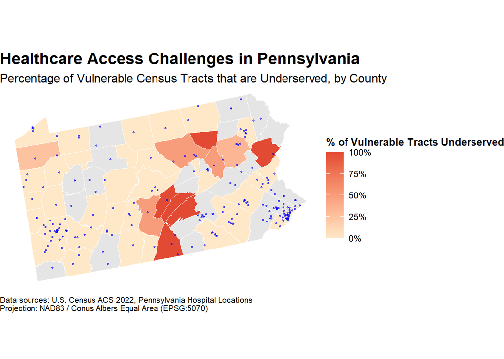

```r
# Create county-level access map
# Merge geometry back to county summary
pa_counties_5070 <- st_transform(pa_counties, 5070)

county_map <- pa_counties_5070 %>%
  left_join(county_summary, by = c("COUNTY_NAM"))

# Create choropleth
ggplot() +
  geom_sf(data = county_map, aes(fill = pct_underserved), color = "white", size = 0.2) +
  geom_sf(data = hospitals_proj, color = "blue", size = 0.5, alpha = 0.6) +
  scale_fill_gradient(
    name = "% of Vulnerable Tracts Underserved",
    low = "#fee8c8", high = "#e34a33",
    na.value = "gray90",
    labels = function(x) paste0(round(x, 1), "%")
  ) +
  labs(
    title = "Healthcare Access Challenges in Pennsylvania",
    subtitle = "Percentage of Vulnerable Census Tracts that are Underserved, by County",
    caption = "Data sources: U.S. Census ACS 2022, Pennsylvania Hospital Locations\nProjection: NAD83 / Conus Albers Equal Area (EPSG:5070)"
  ) +
  theme_void() +
  theme(
    legend.position = "right",
    plot.title = element_text(size = 16, face = "bold"),
    plot.subtitle = element_text(size = 12),
    legend.title = element_text(size = 10, face = "bold"),
    legend.text = element_text(size = 9),
    plot.caption = element_text(size = 8, hjust = 0)
  )
```

**Requirements:** - Fill counties by percentage of vulnerable tracts that are underserved - Include hospital locations as points - Use an appropriate color scheme - Include clear title, subtitle, and caption - Use `theme_void()` or similar clean theme - Add a legend with formatted labels

### Map 2: Detailed Vulnerability Map

Create a map highlighting underserved vulnerable tracts.

**Your Task:**

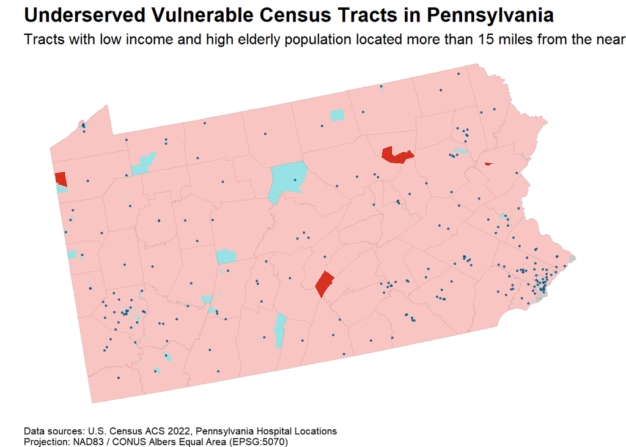

```r
# Create detailed tract-level map
ggplot() +
  geom_sf(data = pa_counties_5070, fill = "gray98", color = "gray80", size = 0.2) +

  geom_sf(data = vulnerable_tracts_proj, aes(fill = factor(vulnerable)),
          color = NA, alpha = 0.4, show.legend = FALSE) +

  geom_sf(data = subset(vulnerable_tracts_proj, underserved == 1),
          fill = "#d7301f", color = "white", size = 0.15) +

  geom_sf(data = hospitals_proj, color = "#045a8d", size = 0.6, alpha = 0.8) +

  labs(
    title = "Underserved Vulnerable Census Tracts in Pennsylvania",
    subtitle = "Tracts with low income and high elderly population located more than 15 miles from the nearest hospital",
    caption = "Data sources: U.S. Census ACS 2022, Pennsylvania Hospital Locations\nProjection: NAD83 / CONUS Albers Equal Area (EPSG:5070)"
  ) +

  theme_void() +
  theme(
    plot.title = element_text(size = 16, face = "bold"),
    plot.subtitle = element_text(size = 12),
    plot.caption = element_text(size = 8, hjust = 0),
    legend.position = "none"
  )
```

**Requirements:** - Show underserved vulnerable tracts in a contrasting color - Include county boundaries for context - Show hospital locations - Use appropriate visual hierarchy (what should stand out?) - Include informative title and subtitle

### Chart: Distribution Analysis

Create a visualization showing the distribution of distances to hospitals for vulnerable populations.

**Your Task:**

[figure not shown]

```r
# Create distribution visualization
ggplot(vulnerable_tracts_proj, aes(x = dist_to_hospital_mi)) +
  geom_histogram(
    fill = "#3182bd", color = "white", bins = 30, alpha = 0.8
  ) +
  geom_vline(aes(xintercept = mean(dist_to_hospital_mi, na.rm = TRUE)),
             color = "red", linetype = "dashed", size = 1) +
  labs(
    title = "Distribution of Distance to Nearest Hospital for Vulnerable Tracts",
    subtitle = "Red dashed line shows mean distance across all vulnerable census tracts",
    x = "Distance to Nearest Hospital (miles)",
    y = "Number of Vulnerable Tracts",
    caption = "Data: ACS 2022, Pennsylvania Hospital Locations\nProjection: EPSG 5070"
  ) +
  theme_minimal(base_size = 12) +
  theme(
    plot.title = element_text(face = "bold", size = 14),
    plot.subtitle = element_text(size = 11),
    plot.caption = element_text(size = 8, hjust = 0),
    panel.grid.minor = element_blank()
  )
```

**Suggested chart types:** - Histogram or density plot of distances - Box plot comparing distances across regions - Bar chart of underserved tracts by county - Scatter plot of distance vs. vulnerable population size

**Requirements:** - Clear axes labels with units - Appropriate title - Professional formatting - Brief interpretation (1-2 sentences as a caption or in text)

## Part 3: Bring Your Own Data Analysis

Choose your own additional spatial dataset and conduct a supplementary analysis.

### Challenge Options

Choose ONE of the following challenge exercises, or propose your own research question using OpenDataPhilly data (https://opendataphilly.org/datasets/).

**Note these are just loose suggestions to spark ideas - follow or make your own as the data permits and as your ideas evolve. This analysis should include bringing in your own dataset, ensuring the projection/CRS of your layers align and are appropriate for the analysis (not lat/long or geodetic coordinate systems). The analysis portion should include some combination of spatial and attribute operations to answer a relatively straightforward question**

#### Education & Youth Services

**Option A: Educational Desert Analysis** - **Data:** Schools, Libraries, Recreation Centers, Census tracts (child population) - **Question:** “Which neighborhoods lack adequate educational infrastructure for children?” - **Operations:** Buffer schools/libraries (0.5 mile walking distance), identify coverage gaps, overlay with child population density - **Policy relevance:** School district planning, library placement, after-school program siting

**Option B: School Safety Zones** - **Data:** Schools, Crime Incidents, Bike Network - **Question:** “Are school zones safe for walking/biking, or are they crime hotspots?” - **Operations:** Buffer schools (1000ft safety zone), spatial join with crime incidents, assess bike infrastructure coverage - **Policy relevance:** Safe Routes to School programs, crossing guard placement

#### Environmental Justice

**Option C: Green Space Equity** - **Data:** Parks, Street Trees, Census tracts (race/income demographics) - **Question:** “Do low-income and minority neighborhoods have equitable access to green space?” - **Operations:** Buffer parks (10-minute walk = 0.5 mile), calculate tree canopy or park acreage per capita, compare by demographics - **Policy relevance:** Climate resilience, environmental justice, urban forestry investment —

#### Public Safety & Justice

**Option D: Crime & Community Resources** - **Data:** Crime Incidents, Recreation Centers, Libraries, Street Lights - **Question:** “Are high-crime areas underserved by community resources?” - **Operations:** Aggregate crime counts to census tracts or neighborhoods, count community resources per area, spatial correlation analysis - **Policy relevance:** Community investment, violence prevention strategies —

#### Infrastructure & Services

**Option E: Polling Place Accessibility** - **Data:** Polling Places, SEPTA stops, Census tracts (elderly population, disability rates) - **Question:** “Are polling places accessible for elderly and disabled voters?” - **Operations:** Buffer polling places and transit stops, identify vulnerable populations, find areas lacking access - **Policy relevance:** Voting rights, election infrastructure, ADA compliance

#### Health & Wellness

**Option F: Recreation & Population Health** - **Data:** Recreation Centers, Playgrounds, Parks, Census tracts (demographics) - **Question:** “Is lack of recreation access associated with vulnerable populations?” - **Operations:** Calculate recreation facilities per capita by neighborhood, buffer facilities for walking access, overlay with demographic indicators - **Policy relevance:** Public health investment, recreation programming, obesity prevention

#### Emergency Services

**Option G: EMS Response Coverage** - **Data:** Fire Stations, EMS stations, Population density, High-rise buildings - **Question:** “Are population-dense areas adequately covered by emergency services?” - **Operations:** Create service area buffers (5-minute drive = ~2 miles), assess population coverage, identify gaps in high-density areas - **Policy relevance:** Emergency preparedness, station siting decisions

#### Arts & Culture

**Option H: Cultural Asset Distribution** - **Data:** Public Art, Museums, Historic sites/markers, Neighborhoods - **Question:** “Do all neighborhoods have equitable access to cultural amenities?” - **Operations:** Count cultural assets per neighborhood, normalize by population, compare distribution across demographic groups - **Policy relevance:** Cultural equity, tourism, quality of life, neighborhood identity

### Data Sources

**OpenDataPhilly:** https://opendataphilly.org/datasets/ - Most datasets available as GeoJSON, Shapefile, or CSV with coordinates - Always check the Metadata for a data dictionary of the fields.

**Additional Sources:** - **Pennsylvania Open Data:** https://data.pa.gov/ - **Census Bureau (via tidycensus):** Demographics, economic indicators, commute patterns - **TIGER/Line (via tigris):** Geographic boundaries

### Recommended Starting Points

**If you’re feeling confident:** Choose an advanced challenge with multiple data layers. **If you are a beginner, choose something more manageable that helps you understand the basics**

**If you have a different idea:** Propose your own question! Just make sure: - You can access the spatial data - You can perform at least 2 spatial operations

### Your Analysis

**Your Task:**

1. **Find and load additional data**
   - Document your data source
   - Check and standardize the CRS
   - Provide basic summary statistics

```r
# Load your additional dataset
schools <- st_read("./data/Schools.geojson")
crimes  <- st_read("./data/incidents_part1_part2/incidents_part1_part2.shp")
```

```
replacing null geometries with empty geometries
Simple feature collection with 151197 features and 13 fields (with 890 geometries empty)
Geometry type: POINT
Dimension:     XY
Bounding box:  xmin: -75.2753 ymin: 39.87731 xmax: -74.95981 ymax: 40.13646
Geodetic CRS:  WGS 84
```

```r
bike_network <- st_read("./data/Bike_Network.geojson")
st_crs(schools)
```

```
Coordinate Reference System:
  User input: WGS 84
  wkt:
GEOGCRS["WGS 84",
    DATUM["World Geodetic System 1984",
        ELLIPSOID["WGS 84",6378137,298.257223563,
            LENGTHUNIT["metre",1]]],
    PRIMEM["Greenwich",0,
        ANGLEUNIT["degree",0.0174532925199433]],
    CS[ellipsoidal,2],
        AXIS["geodetic latitude (Lat)",north,
            ORDER[1],
            ANGLEUNIT["degree",0.0174532925199433]],
        AXIS["geodetic longitude (Lon)",east,
            ORDER[2],
            ANGLEUNIT["degree",0.0174532925199433]],
    ID["EPSG",4326]]
```

```r
st_crs(crimes)
```

```
Coordinate Reference System:
  User input: WGS 84
  wkt:
GEOGCRS["WGS 84",
    DATUM["World Geodetic System 1984",
        ELLIPSOID["WGS 84",6378137,298.257223563,
            LENGTHUNIT["metre",1]]],
    PRIMEM["Greenwich",0,
        ANGLEUNIT["degree",0.0174532925199433]],
    CS[ellipsoidal,2],
        AXIS["latitude",north,
            ORDER[1],
            ANGLEUNIT["degree",0.0174532925199433]],
        AXIS["longitude",east,
            ORDER[2],
            ANGLEUNIT["degree",0.0174532925199433]],
    ID["EPSG",4326]]
```

```r
st_crs(bike_network)
```

```
Coordinate Reference System:
  User input: WGS 84
  wkt:
GEOGCRS["WGS 84",
    DATUM["World Geodetic System 1984",
        ELLIPSOID["WGS 84",6378137,298.257223563,
            LENGTHUNIT["metre",1]]],
    PRIMEM["Greenwich",0,
        ANGLEUNIT["degree",0.0174532925199433]],
    CS[ellipsoidal,2],
        AXIS["geodetic latitude (Lat)",north,
            ORDER[1],
            ANGLEUNIT["degree",0.0174532925199433]],
        AXIS["geodetic longitude (Lon)",east,
            ORDER[2],
            ANGLEUNIT["degree",0.0174532925199433]],
    ID["EPSG",4326]]
```

```r
schools_2272 <- st_transform(schools, 2272)
crimes_2272 <- st_transform(crimes, 2272)
bike_network_2272 <- st_transform(bike_network, 2272)
```

2. **Pose a research question**

Which school zones in Philadelphia face both high crime rates and limited bicycle infrastructure, indicating a need for targeted ‘Safe Routes to School’ interventions?

3. **Conduct spatial analysis**

Use at least TWO spatial operations to answer your research question.

**Required operations (choose 2+):** - Buffers - Spatial joins - Spatial filtering with predicates - Distance calculations - Intersections or unions - Point-in-polygon aggregation

**Your Task:**

```r
# Your spatial analysis

schools_2272 <- schools_2272 %>%
  mutate(school_id = row_number())

school_buffer <- st_buffer(schools_2272, dist = 304.8)

crimes_joined <- st_join(crimes_2272, school_buffer, join = st_within, left = FALSE)

crime_summary <- crimes_joined %>%
  st_drop_geometry() %>%
  group_by(school_id) %>%
  summarise(crime_count = n(), .groups = "drop")

safety_summary <- school_buffer %>%
  left_join(crime_summary, by = "school_id") %>%
  mutate(
    crime_count = replace_na(crime_count, 0),
    risk_level = case_when(
      crime_count >= quantile(crime_count, 0.75) ~ "High Risk",
      crime_count >= quantile(crime_count, 0.25) ~ "Moderate Risk",
      TRUE ~ "Low Risk"
    ),
    has_bike_lane = lengths(st_intersects(., bike_network_2272)) > 0
  )

library(knitr)
kable(
  safety_summary %>%
    st_drop_geometry() %>%
    select(school_name, crime_count, has_bike_lane, risk_level) %>%
    arrange(desc(crime_count)) %>%
    head(10),
  caption = "Top 10 Schools by Crime Count within 1000-ft Safety Zones"
)
```

| school_name | crime_count | has_bike_lane | risk_level |
| --- | --- | --- | --- |
| FREIRE CHARTER SCHOOL | 236 | TRUE | High Risk |
| K012 KIDS SCHOOL | 191 | TRUE | High Risk |
| VISITATION SCHOOL | 177 | TRUE | High Risk |
| ROMAN CATHOLIC HIGH SCHOOL | 150 | FALSE | High Risk |
| JUNIATA PARK ACADEMY | 118 | TRUE | High Risk |
| TECH FREIRE CHARTER SCHOOL | 109 | FALSE | High Risk |
| GIRLS, PHILA HIGH SCHOOL FOR | 107 | TRUE | High Risk |
| SCIENCE LEADERSHIP ACADEMY | 103 | TRUE | High Risk |
| WRIGHT, RICHARD R. SCHOOL | 98 | FALSE | High Risk |
| YES PHILLY | 93 | TRUE | High Risk |

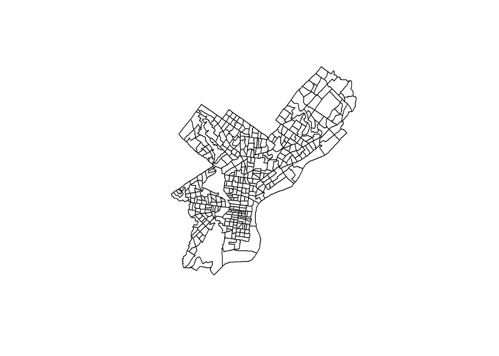

```r
# Filter: only high-risk schools without nearby bike lanes
highrisk_nobike <- safety_summary %>%
  filter(risk_level == "High Risk" & has_bike_lane == FALSE)

library(sf)
library(dplyr)
library(ggplot2)
library(here)

pa_tracts <- st_read("./data/PA-tracts.geojson")
philly_tracts <- pa_tracts %>%
  filter(pl == "Philadelphia County, Pennsylvania")

philly_tracts_2272 <- st_transform(philly_tracts, 2272)


plot(st_geometry(philly_tracts_2272))
```

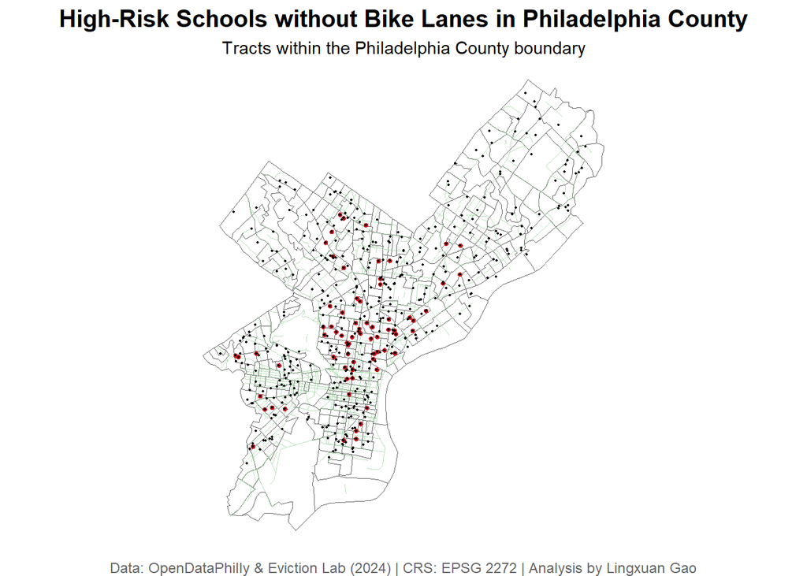

```r
ggplot() +
  geom_sf(data = philly_tracts_2272, fill = NA, color = "gray40", size = 0.1) +

  geom_sf(data = bike_network_2272, color = "#74c476", size = 0.3, alpha = 0.5) +

  geom_sf(data = highrisk_nobike, fill = "#cb181d", color = "#cb181d", size = 0.6, alpha = 1) +

  geom_sf(data = schools_2272, color = "black", fill = "black", size = 0.3, shape = 21) +

  labs(
    title = "High-Risk Schools without Bike Lanes in Philadelphia County",
    subtitle = "Tracts within the Philadelphia County boundary",
    caption = "Data: OpenDataPhilly & Eviction Lab (2024) | CRS: EPSG 2272 | Analysis by Lingxuan Gao"
  ) +
  theme_void() +
  theme(
    plot.title = element_text(face = "bold", size = 15, hjust = 0.5),
    plot.subtitle = element_text(size = 11, hjust = 0.5),
    plot.caption = element_text(size = 9, color = "gray40", hjust = 0.5)
  )
```

**Analysis requirements:** - Clear code comments explaining each step - Appropriate CRS transformations - Summary statistics or counts - At least one map showing your findings - Brief interpretation of results (3-5 sentences)

**Your interpretation:**

The map shows that high-risk schools without nearby bike lanes are scattered across Philadelphia County, with notable clusters in Central Philadelphia and the southern parts of North Philadelphia. A smaller number of red points also appear in West Philadelphia and South Philadelphia, indicating that safety and bike infrastructure gaps are not limited to any single district. Overall, most schools with higher crime counts are located along major urban corridors, where dense street networks and limited bike lanes may increase exposure to unsafe environments.

## Finally - A few comments about your incorporation of feedback!

Take a few moments to clean up your markdown document and then write a line or two or three about how you may have incorporated feedback that you recieved after your first assignment.

## Submission Requirements

**What to submit:**

1. **Rendered HTML document posted to your course portfolio** with all code, outputs, maps, and text
   - Use `embed-resources: true` in YAML so it’s a single file
   - All code should run without errors
   - All maps and charts should display correctly

**File naming:** `LastName_FirstName_Assignment2.html` and `LastName_FirstName_Assignment2.qmd`